# tidyverse: using purrr to manipulate dataframe

Nick Oliver

# Tidyverse: Using `purrr` to manipulate data in a functional way

## Load Tidyverse

```r
library(tidyverse)
```

## Dataset

Data was obtained from FiveThirtyEight’s article (How Americans View Biden’s Response To The Coronavirus Crisis)[https://projects.fivethirtyeight.com/coronavirus-polls/]

```r
approvalPollsDf <- read_csv("https://raw.githubusercontent.com/nolivercuny/data607/master/covid_approval_polls.csv")

glimpse(approvalPollsDf)
```

```
## Rows: 2,983
## Columns: 13
## $ start_date  <date> 2020-02-02, 2020-02-02, 2020-02-02, 2020-02-02, 2020-02-0…
## $ end_date    <date> 2020-02-04, 2020-02-04, 2020-02-04, 2020-02-04, 2020-02-0…
## $ pollster    <chr> "YouGov", "YouGov", "YouGov", "YouGov", "Morning Consult",…
## $ sponsor     <chr> "Economist", "Economist", "Economist", "Economist", NA, NA…
## $ sample_size <dbl> 1500, 376, 523, 599, 2200, 684, 817, 700, 1996, 700, 788, …
## $ population  <chr> "a", "a", "a", "a", "a", "a", "a", "a", "rv", "rv", "rv", …
## $ party       <chr> "all", "R", "D", "I", "all", "R", "D", "I", "all", "R", "D…
## $ subject     <chr> "Trump", "Trump", "Trump", "Trump", "Trump", "Trump", "Tru…
## $ tracking    <lgl> FALSE, FALSE, FALSE, FALSE, FALSE, FALSE, FALSE, FALSE, FA…
## $ text        <chr> "Do you approve or disapprove of Donald Trump’s handling o…
## $ approve     <dbl> 42, 75, 21, 39, 57, 88, 37, 50, 39, 71, 15, 34, 39, 74, 19…
## $ disapprove  <dbl> 29, 6, 51, 25, 22, 4, 37, 22, 35, 8, 60, 33, 28, 7, 50, 25…
## $ url         <lgl> NA, NA, NA, NA, NA, NA, NA, NA, NA, NA, NA, NA, NA, NA, NA…
```

## Using `map2`

Q: What is the difference between approval and disapproval

A: Use the `map2` function to apply a difference function across the approval and disapproval columns

```r
approvalPollsDf$approve_dissapprove_diff <- map2_dbl(approvalPollsDf$approve, approvalPollsDf$disapprove, ~{.x - .y})
approvalPollsDf %>% head() %>% glimpse()
```

```
## Rows: 6
## Columns: 14
## $ start_date               <date> 2020-02-02, 2020-02-02, 2020-02-02, 2020-02-…
## $ end_date                 <date> 2020-02-04, 2020-02-04, 2020-02-04, 2020-02-…
## $ pollster                 <chr> "YouGov", "YouGov", "YouGov", "YouGov", "Morn…
## $ sponsor                  <chr> "Economist", "Economist", "Economist", "Econo…
## $ sample_size              <dbl> 1500, 376, 523, 599, 2200, 684
## $ population               <chr> "a", "a", "a", "a", "a", "a"
## $ party                    <chr> "all", "R", "D", "I", "all", "R"
## $ subject                  <chr> "Trump", "Trump", "Trump", "Trump", "Trump", …
## $ tracking                 <lgl> FALSE, FALSE, FALSE, FALSE, FALSE, FALSE
## $ text                     <chr> "Do you approve or disapprove of Donald Trump…
## $ approve                  <dbl> 42, 75, 21, 39, 57, 88
## $ disapprove               <dbl> 29, 6, 51, 25, 22, 4
## $ url                      <lgl> NA, NA, NA, NA, NA, NA
## $ approve_dissapprove_diff <dbl> 13, 69, -30, 14, 35, 84
```

## Using `some`

Q: Can we use `purrr` to check if our new column contains any `NA` values?

A: Yes, you can use the `some` function which returns `TRUE` if at least one value matches your condition

```r
some(approvalPollsDf$approve_dissapprove_diff, is.na)
```

```
## [1] TRUE
```

## Using `modify_if`

Q: How can we coerce the `NA` values into a number

A: You can use the `modify_if` function which will modify a value only if the predicate returns true.

```r
approvalPollsDf$approve_dissapprove_diff <- modify_if(approvalPollsDf$approve_dissapprove_diff, is.na, ~0.0)
```

Using it again to add a new column marking if the majority approve or disapprove

```r
approvalPollsDf$majority_approve <-
map_if(approvalPollsDf$approve_dissapprove_diff, ~.x > 0, ~"TRUE", .else = ~"FALSE") %>% unlist()
```

## Plot the data

Box plot comparing the approval and disapproval margins. I use the `map_dbl` to convert the negative values to positive for side-by-side comparison

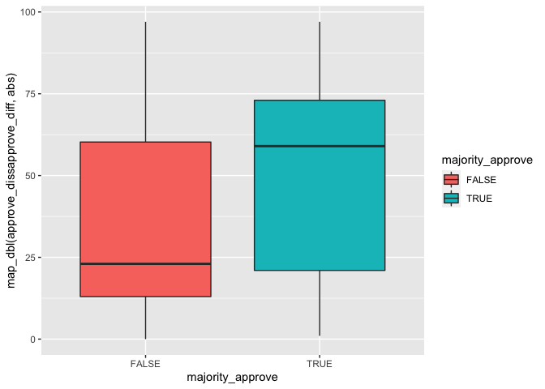

```r
approvalPollsDf %>% ggplot(aes(x=majority_approve,y=map_dbl(approve_dissapprove_diff,abs),fill=majority_approve)) +
  geom_boxplot()
```

## Customizing plots

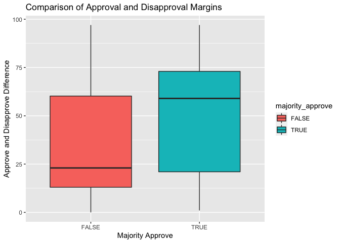

```r
# Box plot comparison of approval and disapproval margins
approvalPollsDf %>%
  ggplot(aes(x = majority_approve, y = map_dbl(approve_dissapprove_diff,abs), fill = majority_approve)) +
  geom_boxplot() +
  xlab("Majority Approve") + # adds x-axis label
  ylab("Approve and Disapprove Difference") + # adds y-axis label
  labs(title = "Comparison of Approval and Disapproval Margins") # adds title
```

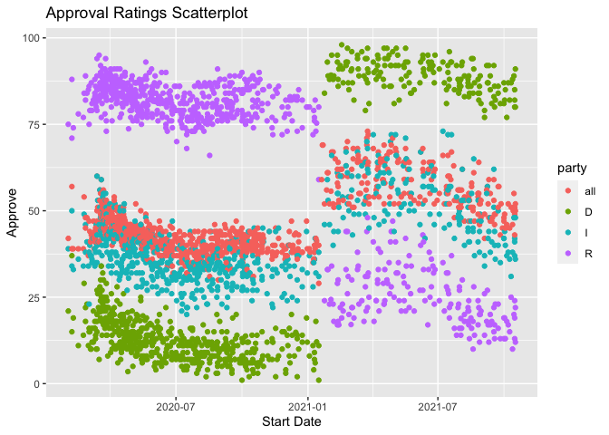

```r
# Scatter plot of approval ratings for all parties
approvalPollsDf %>%
  ggplot(aes(x = start_date, y = approve, color = party)) +
           geom_point() +
  labs(title = "Approval Ratings Scatterplot", x = "Start Date", y = "Approve") # adds labels to x and y axis along with title for plot
```

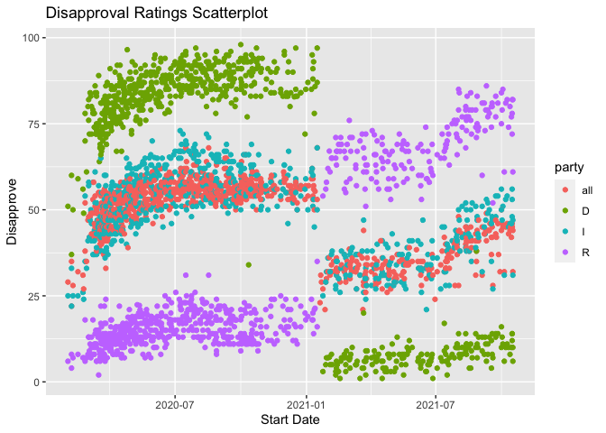

```r
# Scatter plot of disapproval ratings for all parties
approvalPollsDf %>%
  ggplot(aes(x = start_date, y = disapprove, color = party)) +
           geom_point() +
  labs(title = "Disapproval Ratings Scatterplot", x = "Start Date", y = "Disapprove") # adds labels to x and y axis along with title for plot
```

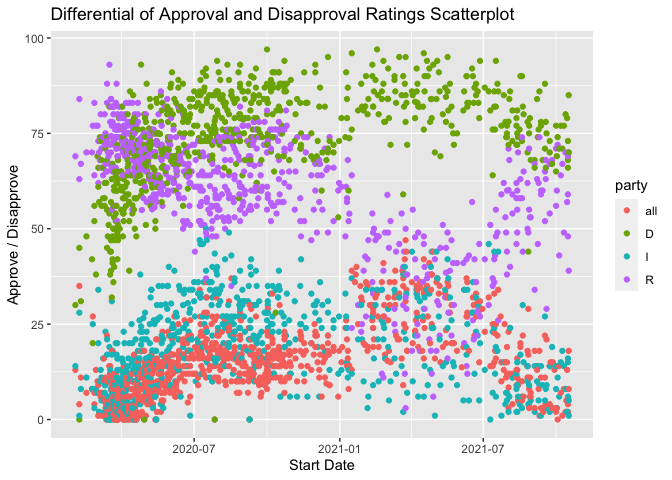

```r
# Scatter plot of disapproval ratings for all parties
approvalPollsDf %>%
  ggplot(aes(x = start_date, y = map_dbl(approve_dissapprove_diff,abs), color = party)) +
           geom_point() +
  labs(title = "Differential of Approval and Disapproval Ratings Scatterplot", x = "Start Date", y = "Approve / Disapprove") # adds labels to x and y axis along with title for plot
```